# 65세이상 시니어 고객에 대한 2차 EDA

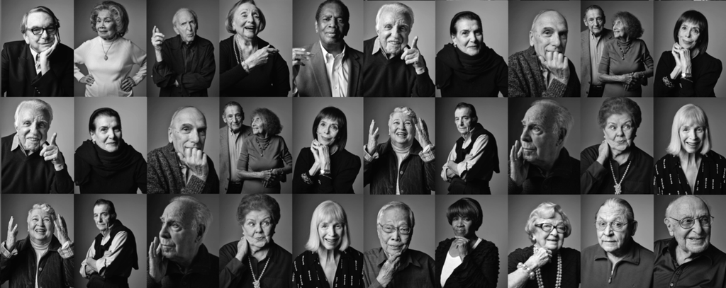

### 탐색의 목적

다른집단 보다 우위 여서, 또는 다른 집단 보다 열악 하여 **시니어 고객에 대한 관심이 필요하다는 논리**를 기저로 하고, 그 논리를 뒷받침 할 특이점을 찾고자 함. 여기서 찾게 되는 특이점은 집단의 특성(모수)이라 여겨지고, 예를 들면 기울기가 크다와 같은 모수는 시니어 집단을 다른 기준으로 추출하여도 동일하게 큰 기울기를 가지는 모수를 가지리라 생각함.

### 대상추출 조건

월개별계좌, 월고객, 월약정실적,월상품실적,잔고테이블을 모두 계좌번호로 inner join. 활동유형 1번, 개인고객, 65세이상으로 추출(999세는 제외) 이며 **20년1월 ~ 21년2월 사이 수익 발생이나 잔고 있는 계좌**만 추출.

### 기타조건

계좌번호별로 월약정테이블과 월상품실적 테이블에서 상품대분류로 유관비용 차감한 수수료 추출. 20년1월 ~ 21년1월의 월평잔을 추출. 수익률의 경우 편차가 심하여 1사분위 3사분위 사이의 고객만 추출.

### 분류기준

계좌번호를 우선하여 수익, 평잔 등을 조인하고 거기에 고객번호를 붙였고, EDIMM_MM_CUS에서 2월말 기준으로 주거래관리점, 주거래사원번호를 사용함. **세대 구분은 20세~39세를 2039, 40세~64세를 4064, 65세이상**으로 분류함.

### 결과 요약

> - 월별 이용고객수의 기울기는 **2039 11.2%, 4064 7.41% 65이상은 3.75%** 임.
> - 연령이 낮은 세대가 신용대출 비율이 높음. **2039 24%, 4064 17%, 65이상 10%** 임
> - 연령과 기여수익의 기울기는 4064가 가장 높고, 연령별 기여수익 중앙값은 80세를 정점으로 함.
> - 평잔 과 기여수익에 대한 기울기는 평잔 1% 증가 시 **2039는 0.35%, 4064는 0.48%, 65이상은 0.47%* 임.
> - 수익률은 65세이상 구간부터 WM과 상대적으로 비교하여 디지털이 더 하락함.

### 1 세대별 이용 고객수

세대별 이용 고객수도 증가하고 있고 각 집단고객수의 6개월 예상도 아래와 같음. **(월별 수수료 발생고객과, 평잔있는 고객의 수)**  
월별 고객수 변화율의 기울기는 2039 11.2%,, 4064는 7.41%, 65이상은 3.75%를 가짐.

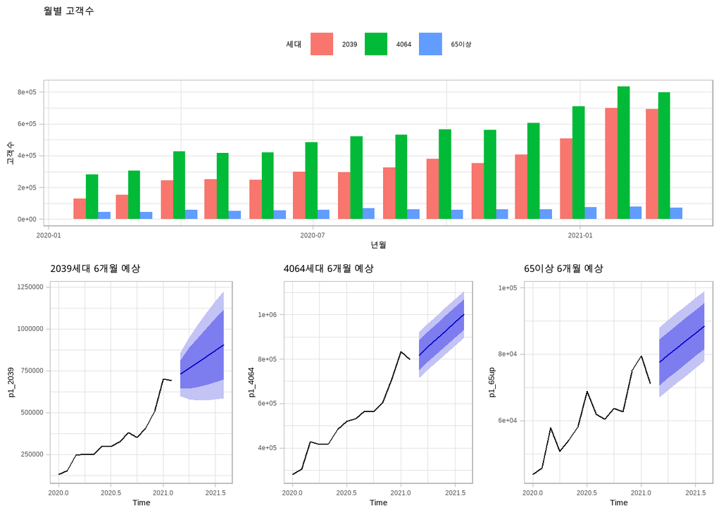

### 2. 기여수익 구조

WM과 디지털 비교 시 WM보다 디지털은 신용대출의 비중이 더 높음. 세대별로 보면 연령이 낮은 세대가 더 신용대출이 높다. 세대별 대출에 대한 인식에 대한 차이라고 추측함.

> 20년1월 ~ 21년2월 발생 기여수익 0초과 고객만 추출

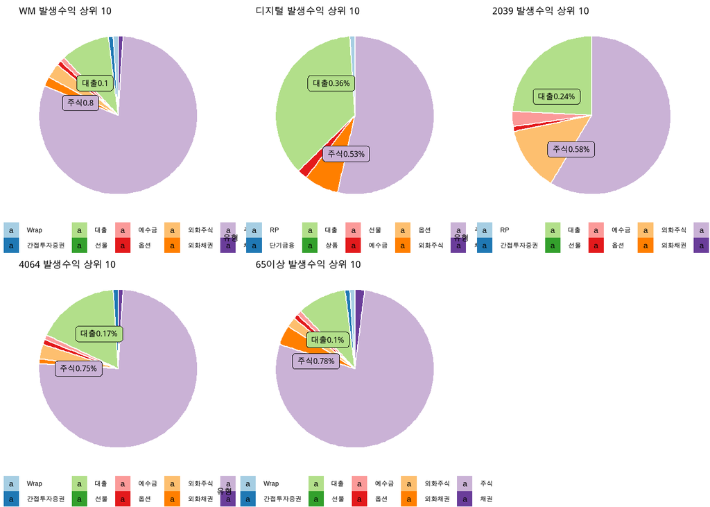

### 3. 연령과 기여수익의 기울기

개인별 기여수익의 합에 대해 연령과의 기울기를 보면, 연령 1세 증가에 대한 기울기는 아래의 표와 같음. 디지털 보다 WM이 높고, 세대별에서는 4064의 기울기가 더 높음.

| WM기울기 | 디지털기울기 | 2039기울기 | 4064기울기 | 65이상기울기 |
| --- | --- | --- | --- | --- |
| 40,338원 | 13,173원 | 15,694원 | 48,071원 | 32,512원 |

하지만 고객별 기여수익의 중앙값을 보면 65이상 > 4064 > 2039의 순으로 기여수익이 높음. 기여수익 중앙값 1692의 2039의 고객도 물론 중요하지만, 기여수익 중앙값 88,597원의 시니어 고객도, 중앙값 14,226원의 예비 시니어 4064고객도 중요하게 생각해야 함. 연령별 중앙값의 분포는 80세를 정점으로 하락함.

| 세대구분 | 수익중앙 |
| --- | --- |
| 2039 | 1,692원 |
| 4064 | 14,226원 |
| 65이상 | 88,597원 |

> 20년 1월 ~ 21년 2월 까지 기여수익의 합. 기여수익 0원 초과 고객만 입력

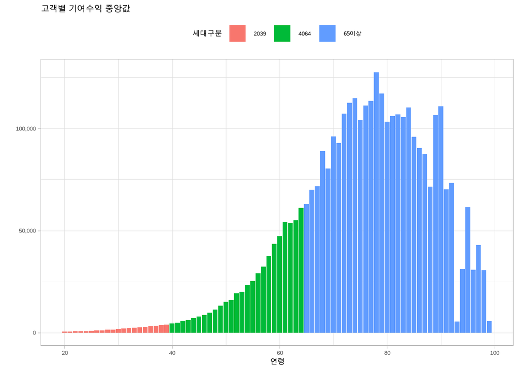

### 4. 평잔과 수수료의 기울기

평잔과 기여수익에 대한 세대별 기울기는 다음과 같음. 평잔 1%증가에 WM의 기여수익은 0.48%, 디지털 0.44%, 2039는 0.35%, 4064는 0.48%, 65이상은 0.47% 임.

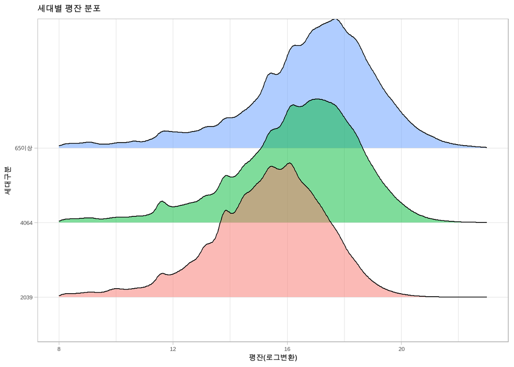

### 5.수익률

수익률은 0을 기준으로 약간은 오른쪽으로 더 치우쳐 져 있으나, 어느세대가 더 우위라고 말하기 어려움(차트 상단).  
연령별 평균 수익률을 보면 WM의경우는 65세 이상 구간에서도 수익률 평균이 완만하게 하락하는 모양이지만, 디지털의 경우 65세 부터 급격히 떨어짐. WM의 경우 PB에 의한 투자가 이루어 지나 디지털의 경우 스스로 하는 투자 이기 때무이라고 추측함(차트 하단왼쪽).  
연령별 수익률 변동은 연령이 증가할수록 줄어듬. 약정은 연령이 증가하면서 같이 증가하는 모양이기 때문에 연령이 높을 수록 신중하게 투자하는 결과 라고 추측함(차트 하단 오른쪽).

> 수익률은 편차가 크기 때문에 전체에서 1사분위와 3사분위 사이의 고객만 추출 측정.

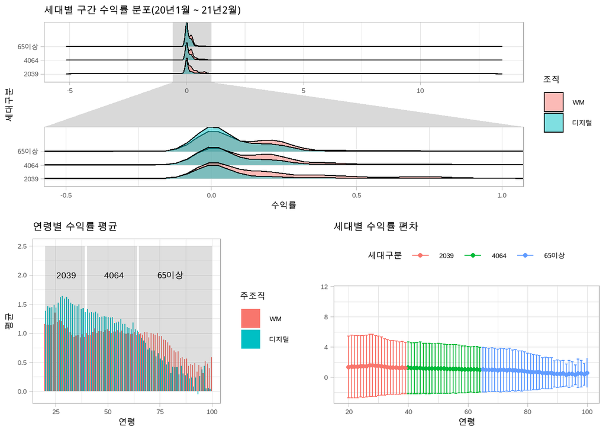

### 5.1약정 과 수익률의 기울기

약정 1% 증가에 대해 각 세대별 수익률의 %포인트 변화는 2039 0.57%pt, 4064 0.51%pt, 65이상 0.40%pt 임. 연령 상위 세대가 약정 대비 수익률이 상대적으로 떨어지는 것은 스스토 투자하고, 작년 시장 상황이 좋을때 적극적으로 주식투자가 안 이루어졌거나 등의 이유라고 추측함. 이부분에 대해서는 추가로 볼 필요 있음.

차트에서 65이상 보다 4064가 많이 눈에 띄는데, 60세~64세는 시니어 구간으로 들어가 예비 시니어로 볼수 있어 대상에 대해 추가로 볼 필요있음.

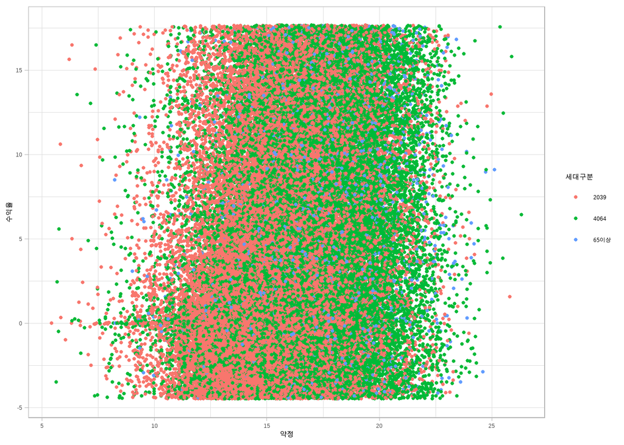

### 6. 계좌생존율

2018년 1월 1일 ~ 2020년 12월 31까지 개설된 계좌들의 생존율을 보면, 1일차부터 대략 50%의 생존율을 보이고, **1년 시점에는 2039는 43%, 4064는 51.5%, 65이상은 57.4%임**. 시니어 집단의 생존율이 좀더 높긴 하나 대략 600일부터 하락 기울기가 커짐.

| **경과일** | **2039** | **4064** | **65이상** |
| --- | --- | --- | --- |
| 100일 | 45.0% | 53.1% | 59.3% |
| 180일 | 44.9% | 53.0% | 59.2% |
| 365일 | 43.2% | 51.5% | 57.4% |
| 730일 | 36.3% | 46.1% | 50.0% |

> 생존정의 : 생 0, 사 1 전체기간 10만원 이하 1, 입금,입고 전무 1, 폐쇄 1, 휴면 1 전 기간 10만원 이하 시 경과일 1일 처리, 그외의 경우는 사망 조건 발생 시까지 생존으로 분류 하여 경과일 측정. 1일처리 외의 사망 발생 시, 약정, 잔고 10만원 이상 발생일, 폐쇄일 중 가장 나중의 발생일을 사망일로 정하여 개설일 ~ >사망일로 경과일 측정.

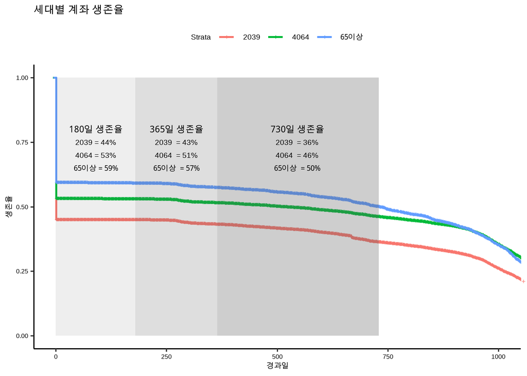